# Welcome

> **We invite you to read the following explanations carefully. This will ensure that the study takes place in the best possible conditions and that you can be sure that you can finish it as soon as possible. Do not hesitate to reread the following explanations several times.**

This study will proceed as follows:

1. After reading these instructions, you will be asked to complete a small set of control questions.
2. You will then have the opportunity to experience the different stages of the study to familiarize yourself with them. This discovery stage will also be the opportunity for you to win your first bonus.
3. You will then be asked to complete a second set of control questions.
4. Finally, you will begin the main part of the study.
5. At the end of the study, you will receive a code that you will have to fill in on the platform. to be able to receive your bonus. A summary of your earnings will be posted at that time.

## Your bonus

At the end of this study, you will receive a bonus that will depend on chance and your choices. This bonus will mainly depend on the lotteries you have chosen. A lottery is a bet that will increase your bonus by a certain amount or by zero based on a number randomly selected by the computer at the end of the study.

> For example, the lottery: “1 in 7 chance of winning $7” will increase your bonus by $7 one time out of seven, and won’t increase it six times out of seven.

You will have 6 opportunities to choose lotteries (one during the Discovery Stage and 5 others in the main part of the study).

You will choose each lottery from a menu. **A menu is a set of one or more lotteries in which you can choose one of the following only lottery.** Here is an example of choosing a lottery from a menu:

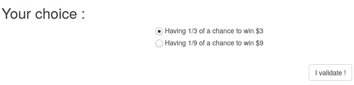

lottery choice

## Your preference for a menu

In this exercise, you will have to choose **under which conditions you would agree to exchange one menu for another**.

A first menu has been assigned to you. On the interface, this menu is displayed on the left.

Your task is to indicate from which amount you would accept to exchange this menu for another menu. On the interface, this other menu is displayed on the right.

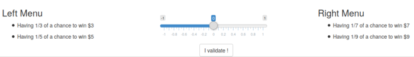

menus choice

You will find yourself in one of these 3 situations:

1. You think that the 2 menus are **equally good**. In this case, just place the cursor on **0** between the 2 menus.
2. You prefer to **keep** the menu that has been assigned to you. You can then move the cursor to the **right** to indicate the **minimum** amount. that you would like to **receive** to accept the exchange.
3. You prefer to **exchange** the menu assigned to you with the other menu. You can then move the cursor to the **left** to indicate the **maximum** amount. that you are willing to **pay** to exchange your assigned menu with the other menu.

After you validate your choice, the computer will choose a **random value**. This value will be used to find out if the computer agrees to make the exchange and for what amount. The value chosen by the computer is sufficient to make the exchange when :

- The computer is **ready to pay you more than you ask for**. You then receive the amount that the computer is willing to give you.
- the computer **ready to accept an amount smaller than you’re willing to pay** to make the switch. You then pay the amount that the computer asks for.

In these two situations, **the exchange will take place** under conditions that are favourable to you. Indeed either you receive at least what you asked for the exchange – but you can also receive more – or you pay the maximum amount you indicated to keep the original menu – but you can also pay less.

### Some examples:

- You have indicated that you would only agree to make the exchange if you receive at least $0,30 and the computer agrees to pay you $0,50 to make the exchange. In this case, the exchange will take place and you will receive $0,50.
- You have indicated that you would only agree to make the exchange if you receive at least $0,50 and the computer agrees to pay you $0,20 to make the exchange. In this case, the exchange doesn’t take place, you keep your menu and you don’t receive any money.
- You have indicated that you would only agree to make the exchange if you receive at least $0,40 and the computer agrees to make the exchange if you pay him $0,10. In this case, the exchange doesn’t take place, you keep your menu and you don’t receive any money.
- You have indicated that you would accept to pay a maximum of $0,20 to make the exchange and the computer agrees to make the exchange if you pay him $0,10. In this case, the exchange takes place and you lose $0.10 of your winnings.
- You have indicated that you would be willing to pay a maximum of $0.40 to make the exchange and the computer wants to receive 0,50€ to accept to exchange. In this case, the exchange does not take place, you keep your menu and you don’t pay anything.
- You indicate that you would accept to pay a maximum of $0,30 to make the exchange and the computer agrees to pay $0,40 to make the exchange. In this case, the exchange will take place and you will receive $0,40.

With these examples you can make sure that if there is an exchange of menus, this exchange is done for an amount of money at least as interesting to you as the one you indicated.

- **If you prefer to keep your menu :** you will receive an amount higher or equal to the one you indicated if the exchange takes place.
- **If you prefer to exchange menu :** you will pay an amount lower or equal to the one you indicated if the exchange takes place (you can even receive money).

**The amount you indicate is the amount you are willing to make the exchange for**. If the exchange takes place, it will be at least for this amount, but it may be more advantageous for you.

## The menus you will receive

During this study, you will receive 6 menus. The menus you will receive will depend on chance and the preferences you indicate:

- In the study, 42 pairs of menus will be offered to you (7 during the discovery stage and 35 in the main part of the study).
- Of these 42 pairs, 6 will be drawn at random (1 of the 7 pairs during discovery and 5 of the 35 choices during the main part of the study).
- For each of these 6 pairs of menus, you will receive a menu according to the preferences that you have indicated.
- In each of the 6 menus you will have received, you will choose a lottery.

Your total bonus will therefore be equal to the amount you will earn from your 6 lotteries plus or minus what you will have earned with the 6 pairs of menus that will have been selected.